# Reproducible Research Peer Assessment 1 -Analysis of Personal Movement Using Activity Monitoring Devices

Md Khaled Hasan Zami

July 1, 2020

# A. Loading and preprocessing the data

Here, we will perform two types of works.

1. We will load the data from the dataset [Activity monitoring data](https://d396qusza40orc.cloudfront.net/repdata%2Fdata%2Factivity.zip)
2. We will perform some pre-processing of the dataset for the suitability of our analysis.

## 1. Loading the data

Let’s create a directory to to store the dataset. We named it as **data**. We will be downloading and saving all the files in it.

```r
if (!file.exists("data")) {
        dir.create("data")
}
```

Let’s download the dataset.

Let’s assign the dataset url to a variable. Then, download the file from the url and save it to directory named **data**.

> method = “curl” $\rightarrow$ for mac users

> method = “wininet” $\rightarrow$ for windows users

```r
dataset_url <- "https://d396qusza40orc.cloudfront.net/repdata%2Fdata%2Factivity.zip"
download.file(dataset_url, destfile="./data/Activity_monitoring_data.zip", method = "wininet")
```

Let’s unzip the downloaded zip file.

```r
unzip("./data/Activity_monitoring_data.zip")
```

```r
list.files("./data",  all.files=T)
```

```
## [1] "."                            ".."
## [3] "Activity_monitoring_data.zip"
```

```r
activity <- read.csv("activity.csv", header = TRUE, sep = ",", na.strings = "NA")
```

**The dataset is loaded successfully**

## 2. Preprocessing the data

We have read our dataset. Now, it is time to look inside. Let’s `str()` the loaded dataset.

```r
str(activity)
```

```
## 'data.frame':    17568 obs. of  3 variables:
##  $ steps   : int  NA NA NA NA NA NA NA NA NA NA ...
##  $ date    : Factor w/ 61 levels "2012-10-01","2012-10-02",..: 1 1 1 1 1 1 1 1 1 1 ...
##  $ interval: int  0 5 10 15 20 25 30 35 40 45 ...
```

As we can see that we have 3 types of varibales. But the date column is in **factor** which was supposed to be in **date** format. So, let;s convert it into **date** format.

```r
activity$date <- as.Date(activity$date, format = "%Y-%m-%d")
```

Now we have converted the date column in **Date** class.

# B. What is mean total number of steps taken per day?

For this part of the assignment, we will be performing three things:

1. We will be calculating the total number of steps taken per day
2. We will be making a histogram of the total number of steps taken per day.
3. We will be calculating the **mean** and **meadian** of the total number of steps taken.

## 1. The total number of steps taken per day

Now, let’s create a new data frame named **steps_per_day** and save the total number of steps taken each day.

```r
steps_per_day <- aggregate(steps ~ date, activity, sum)
head(steps_per_day)
```

```
##         date steps
## 1 2012-10-02   126
## 2 2012-10-03 11352
## 3 2012-10-04 12116
## 4 2012-10-05 13294
## 5 2012-10-06 15420
## 6 2012-10-07 11015
```

## 2. Histogram of the total number of steps taken each day

As the data has been saved to a new dataframe, let’s make the histogram of the total number of steps taken per day.

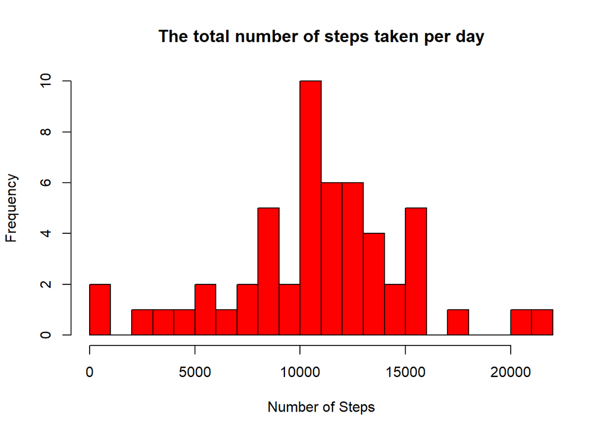

```r
hist(steps_per_day$steps, main = paste("The total number of steps taken per day"),  breaks = 20, col="red", xlab="Number of Steps")
```

## 3. Mean and meadian of the total number of steps taken

R has a generic function called `mean()` to calculate the mean.

```r
rmean <- mean(steps_per_day$steps)
rmean
```

```
## [1] 10766.19
```

**So, the mean of the total number of steps taken is 10766.19**

Additionally, R has a generic function called `median()` to calculate the median.

```r
rmedian <- median(steps_per_day$steps)
rmedian
```

```
## [1] 10765
```

**So, the median of the total number of steps taken is 10765**

# C. What is the average daily activity pattern?

For this part of the assignment, we will be performing two things:

1. We will be making a time series plot of the 5-minute interval (x-axis) and the average number of steps taken, averaged across all days (y-axis)
2. We will be finding on Which 5-minute interval, on average across all the days in the dataset, contains the maximum number of steps

## 1. Making a time series plot

First of all, we created a data frame named **steps_by_interval** by averaging the steps taken on each time interval. Then, we ploted having the the intervals in x-axis and average number of steps in y-axis. The plot was titles using the `main` argument and colored using the `col` argument.

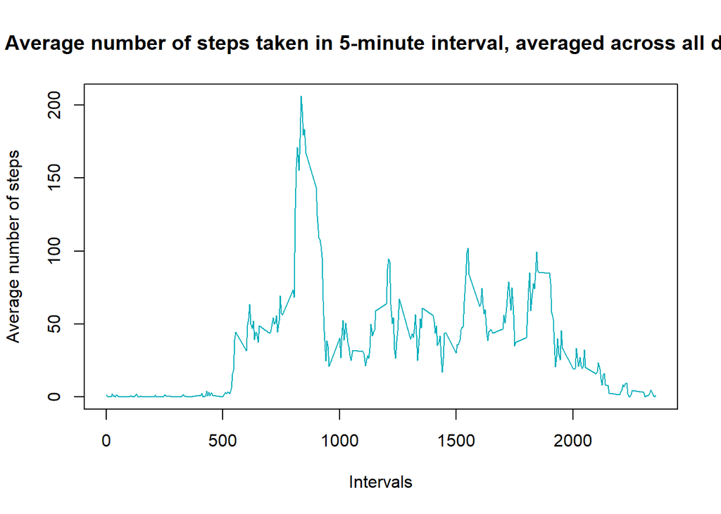

```r
steps_by_interval<- aggregate(steps ~ interval, activity, mean)
plot(steps_by_interval$interval, steps_by_interval$steps,
      type = "l",
      main = 'Average number of steps taken in 5-minute interval, averaged across all days',
      xlab='Intervals',
      ylab='Average number of steps',
      col = "#00AFBB")
```

## 2. 5-minute interval that contains the maximum number of steps

We calculated the maximum number of steps taken in the interval using the `which.max` function then printed out the on which interval it was maximum.

```r
intervale_max_steps<-steps_by_interval[which.max(steps_by_interval$steps),]$interval
intervale_max_steps
```

```
## [1] 835
```

# D. Inputing missing values

For this part of the assignment, we will be performing four things:

1. We will be calculating and reporting the total number of missing values in the dataset
2. We will be using Mean values for fullfiling missing values
3. We will be creating a new dataset including the imputed missing values
4. We will be making a histogram of the total number of steps taken each day and calculating and reporting the mean and median total number of steps taken per day

## 1. calculation and report of the total number of missing values in the dataset

```r
 totalNA<- sum(!complete.cases(activity))
 totalNA
```

```
## [1] 2304
```

**Total Number of Missing values are 2304**

## 2. Fullfiling missing values

```r
StepsAverage <- aggregate(steps ~ interval, data = activity, FUN = mean)
fillNA <- numeric()
for (i in 1:nrow(activity)) {
    obs <- activity[i, ]
    if (is.na(obs$steps)) {
        steps <- subset(StepsAverage, interval == obs$interval)$steps
    } else {
        steps <- obs$steps
    }
    fillNA <- c(fillNA, steps)
}
```

## 3. Creating a new dataset including the imputed missing values

```r
new_activity <- activity
new_activity$steps <- fillNA
```

## 4. Making a histogram of the total number of steps taken each day and calculating and reporting the mean and median total number of steps taken per day

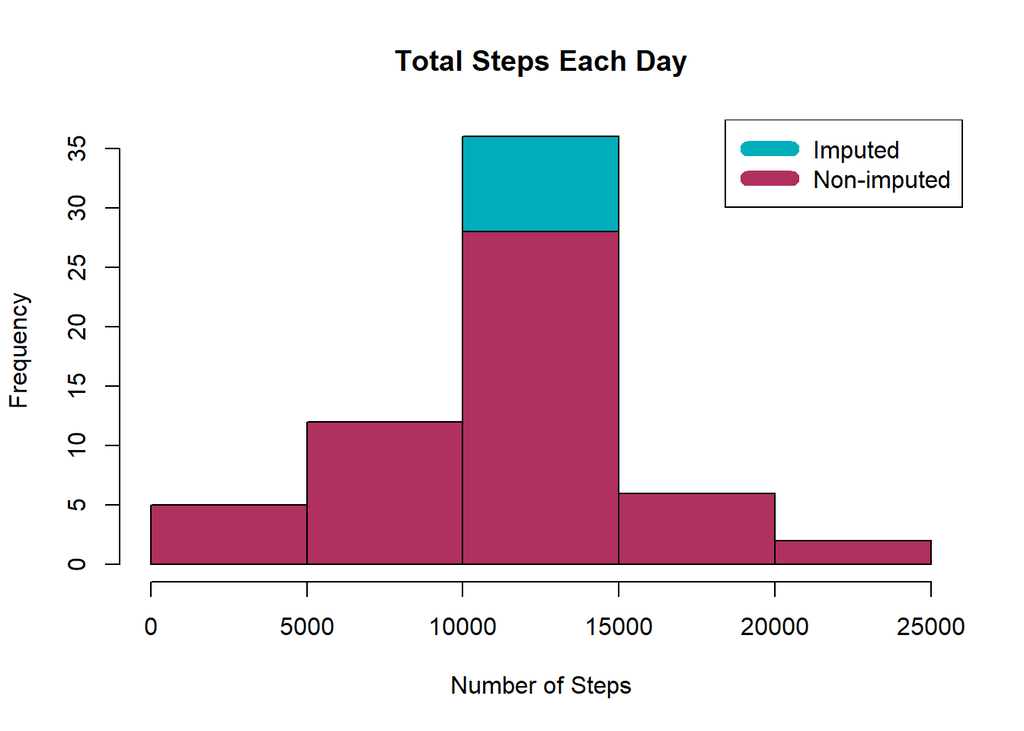

```r
StepsTotalUnion <- aggregate(steps ~ date, data = new_activity, sum, na.rm = TRUE)
hist(StepsTotalUnion$steps, main = "Total Steps Each Day", col="#00AFBB", xlab="Number of Steps")
#Create Histogram to show difference.
hist(steps_per_day$steps, main = "Total Steps Each Day", col="maroon", xlab="Number of Steps", add=T)
legend("topright", c("Imputed", "Non-imputed"), col=c("#00AFBB", "maroon"), lwd=10)
```

```r
rmeantotal <- mean(StepsTotalUnion$steps)
rmeantotal
```

```
## [1] 10766.19
```

### Calculating Median

```r
rmediantotal <- median(StepsTotalUnion$steps)
rmediantotal
```

```
## [1] 10766.19
```

### Do these values differ from the estimates from the first part of the assignment?

```r
rmediandiff <- rmediantotal - rmedian
rmediandiff
```

```
## [1] 1.188679
```

```r
rmeandiff <- rmeantotal - rmean
rmeandiff
```

```
## [1] 0
```

**The mean(Mean Var: 0) is the same however the median does have a small variance(Median Var:1.1886792). between the total which includes the missing values to the base**

# E. Are there differences in activity patterns between weekdays and weekends?

For this part of the assignment, we will be performing two things:

1. We will be creating a new factor variable in the dataset with two levels - “weekday” and “weekend” indicating whether a given date is a weekday or weekend day
2. We will be making a panel plot containing a time series plot

## 1. Creating a new factor variable in the dataset with two levels - “weekday” and “weekend” indicating whether a given date is a weekday or weekend day

```r
weekdays <- c("Monday", "Tuesday", "Wednesday", "Thursday",
              "Friday")
new_activity$dow = as.factor(ifelse(is.element(weekdays(as.Date(new_activity$date)),weekdays), "Weekday", "Weekend"))
StepsTotalUnion <- aggregate(steps ~ interval + dow, new_activity, mean)
```

## 2. A panel plot containing a time series plot

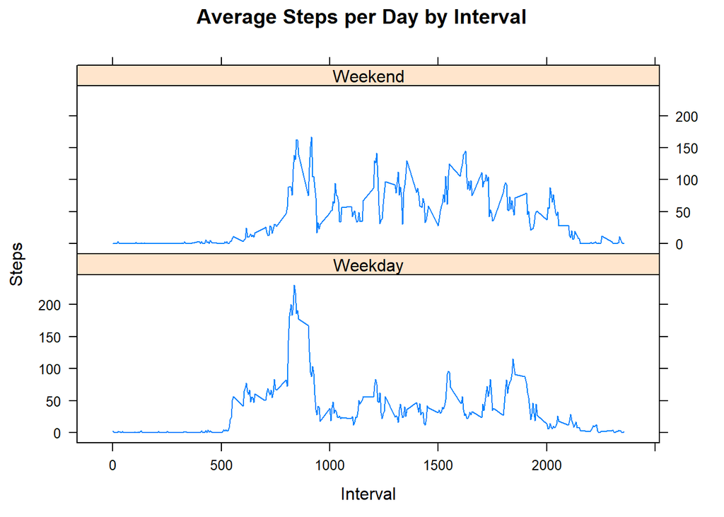

```r
library(lattice)
xyplot(StepsTotalUnion$steps ~ StepsTotalUnion$interval|StepsTotalUnion$dow, main="Average Steps per Day by Interval",xlab="Interval", ylab="Steps",layout=c(1,2), type="l")
```